# Factors that affect or are directly related to the compressive strength values of concrete samples.

## By HAMZAT ABDULRAHMAN

### Investigation Overview

The overall goal of my presentation is to show the distribution of strength categorically across all samples in the dataset, the distribution of water-to-cement ratio, the relationship between strength and water-to-cement ratio, and lastly the significance of slag in a concrete mixture.

Summary of key insights for presentation are:

1. Majority of the concrete samples fall in the moderate category of strength level, followed by the high category. The lesser count of observations goes to the 'low' category, while the least count of observations goes to the 'very high' category of strength level.
2. Grade A (the least water-cement ratio) has the highest occurence while Grade F has the least occurence. Grade C has the second highest occurence, followed by Grade B,D, and E in that order.
3. The maximum compressive strength increases with decreasing water-to-cement (w/c) ratio.
4. Slag is used to complement cement during mixing of concrete, and for each water-to-cement ratio category - increased quantity of slag used improves the maximum compressive strength.

### Dataset Overview

The Cement Manufacturing Dataset is a survey of concrete samples providing the measurement records of ingredients used. These ingredients include cement, blast furnace slag, fly ash, water, superplasticizer, coarse aggregate, and fine aggregate - all measured in kg in a m3 mixture. It also contains the concrete compressive strength (in MPa) for each given mixture under a specific age (days).

## 1. Distribution of Compressive Strength across all samples

This distribution is approximately normal except for some 4-5 unusual spikes of strength values that is observed.

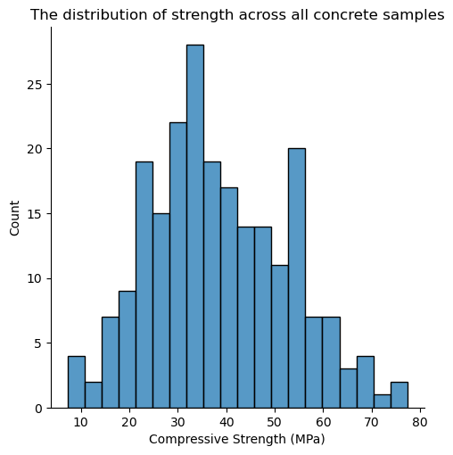

The majority of the concrete samples fall in the moderate category of strength level, followed by the high category. The lesser percentage proportion of observations goes to the 'low' category, while the least proportion percent of observations goes to the 'very high' category of strength level.

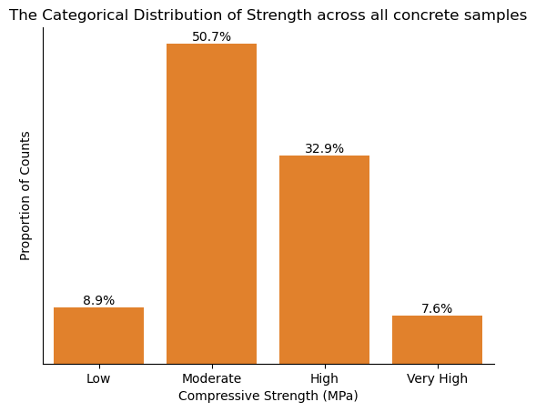

## 2. The distribution of water-to-cement ratio

Grade A (the least water-cement ratio) has the highest percentage proportion while Grade F has the least percentage proportion. Grade C has the second highest proportion percent, followed by Grade B,D, and E in that order.

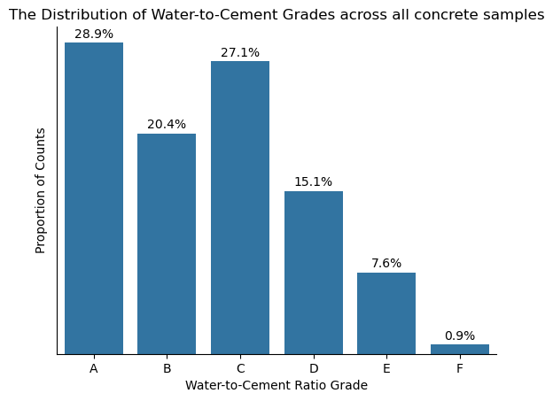

The breakdown of the water-cement ratio grades from the dataset:

Grade-A: 0.36 - 0.59, Grade-B: 0.60 - 0.83, Grade-C: 0.84 - 1.07, Grade-D: 1.08 - 1.31, Grade-E: 1.32 - 1.55, Grade-F: 1.56 - 1.80 .

## 3. The relationship between Compressive Strength and Water-to-Cement grade

Therefore, in order to improve the compressive strength of concretes produced, the water-to-cement ratio needs to be as low as possible. This also go in accordance with IS code 10262 (2009), where it is stated that the nominal mix should have a ratio between 0.40 and 0.60. However,a design for a concrete with high compressive strength - other variables like superplasticity, fine-coarse aggregate ratio etc, need to be considered as well because the compressive strength of concretes depends not only on the water-cement ratio.

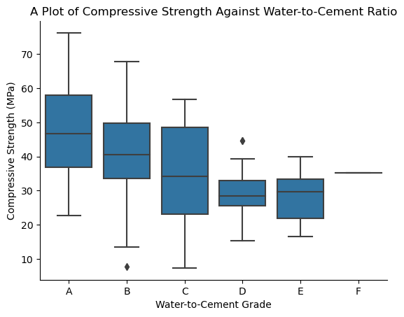

## 4. The significance of slag in a concrete mixture

It can be observed from the multivariate plot that at very high quantities (around 330 - 500 kg) of cement, little amount of slag was required (less than 30kg); in contrast, when lesser quantity of cement was used (around 150 - 300kg), an increased quantity of slag (around 100 - 200kg) was required. It appears that a slag complements the cement, most especially in events where lesser quantities of cement was used. Generally, for a specific quantity range of cement, we can observe that there is an improved compressive strength with increasing quantities of slag.

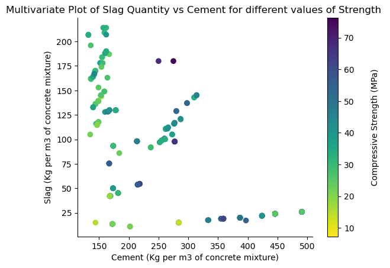

```
A multi-faceted grid plot of slag quantity against cement quantity grouped by water-cement grade and compressive strength level
```

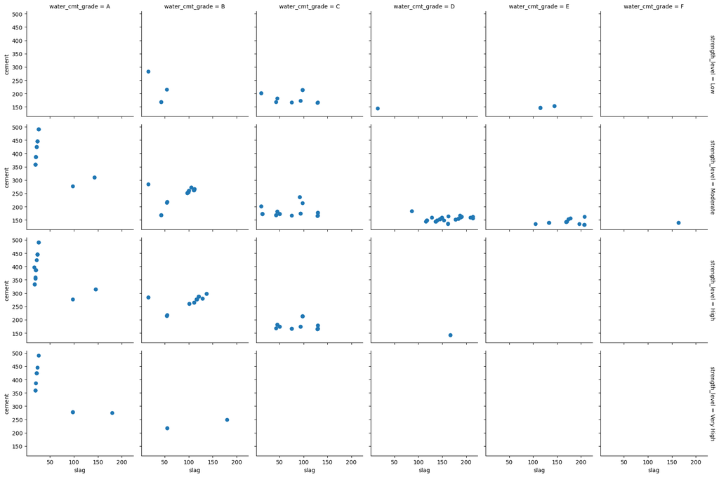

A calm observation of this multifaceted plot further proofs two aforementioned claims:

1. Overall the maximum compressive strength reduces from Grade A - F.
2. Down each column of grade, increase in slag quantity used increases the max compressive strength.

In conclusion, I have highlighted the significance of a low water-cement ratio and the importance of slag in a concrete mixture.

High strength concrete is required in engineering projects that have concrete components that must resist high compressive loads. They are also occassionally used in bridge applications, in the erection of high rise structures, shear walls, foundations etc. They reduce the total amount of material placed and lower the overall cost of structure.

Although a lower water-to-cement ratio makes stronger concrete, but it also makes working with the concrete more difficult. Hence, a proper balance achieves the desired strength while maintaining workability.